# Rfinalprojectcm

# Pediatric Sleep Apnea

Background - Obstructive sleep apnea is common problem (1-6%) characterized by partial or complete obstruction of the upper airways during sleep - Associated with CNS, CVS morbidity - Diagnosis is dependant on Polysomnography- cumbersome and costly

Project Question- are there noninvasive markers of obstructive sleep apnea?

# Pediatric Sleep Apnea METHODS

Methods Childhood Adenotonisllectomy test

- multi-center, single-blind, randomized, controlled trial ages 5 to 9.9 years with mild to moderate sleep apnea -randomized to watchful waiting or eAT followed over 7-month observation period assesed pre and post neurocognitive functioning, growth parameters, metabolic outcomes and quality of life -1,447 children had screening polysomnographs and 464 were randomized to treatment. -variables of interest: history(allergies, bedwetting, mouth breathing), physical exam factors(obesity, inflammation on blood test, enlarged tonsils), easily measurable metrics(heart rate variability) ## Datasets import

# Input files

```
## x ggplot2::%+%()    masks psych::%+%()
```

[output not shown]

[output cut: 12061 more lines]

[output not shown]

[output cut: 1341 more lines]

# Select Variables of Interest and Merge

# Data Cleaning and look at variables with unknown=number that might affect data(0=no, 1 =yes, 88=unknown)

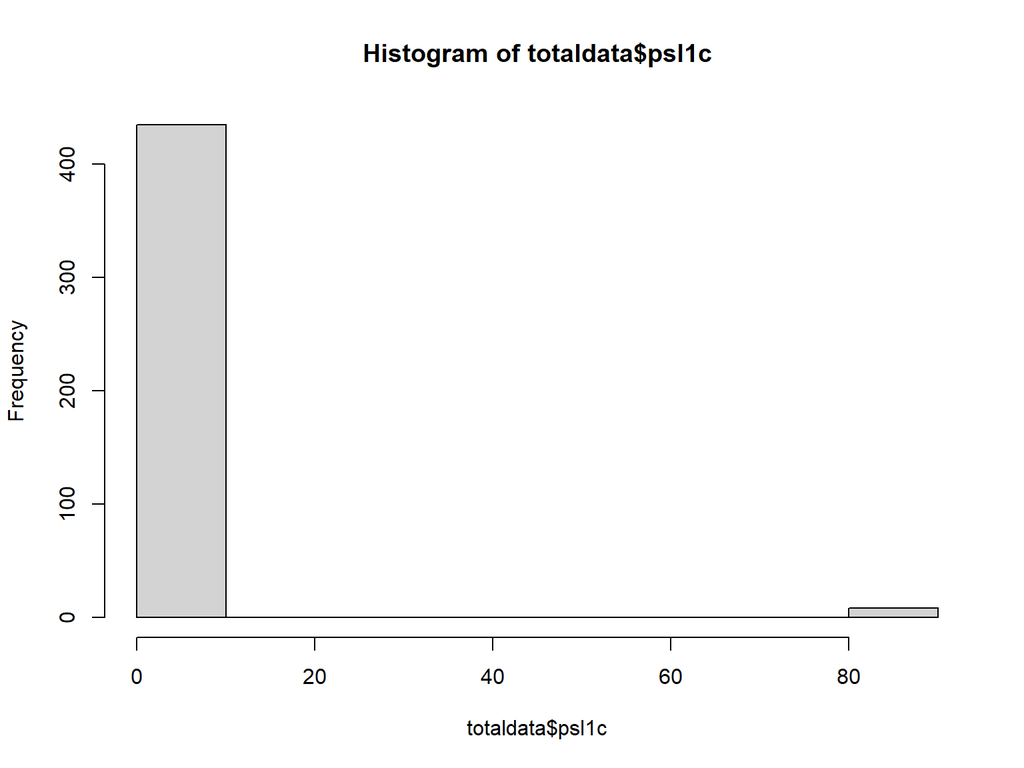

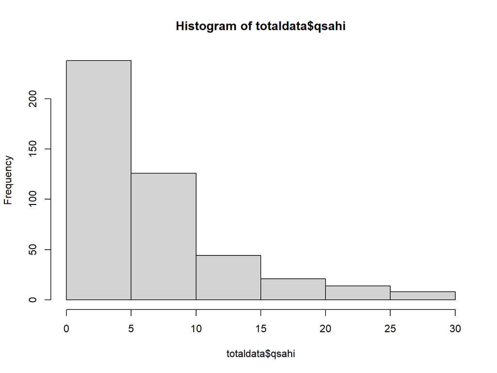

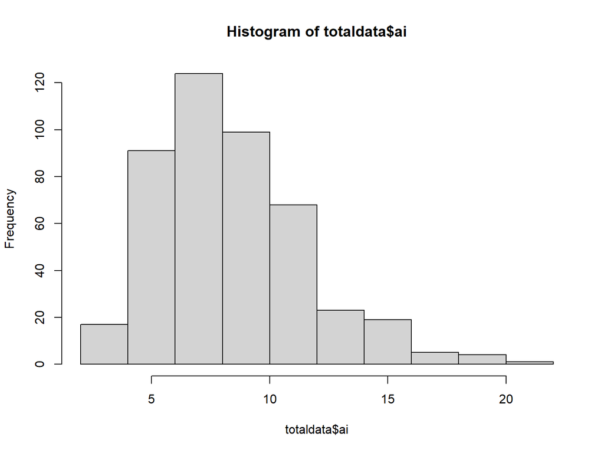

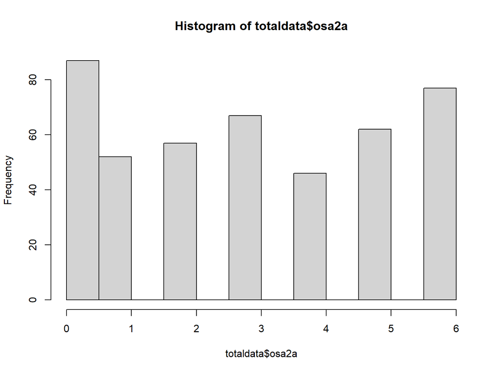

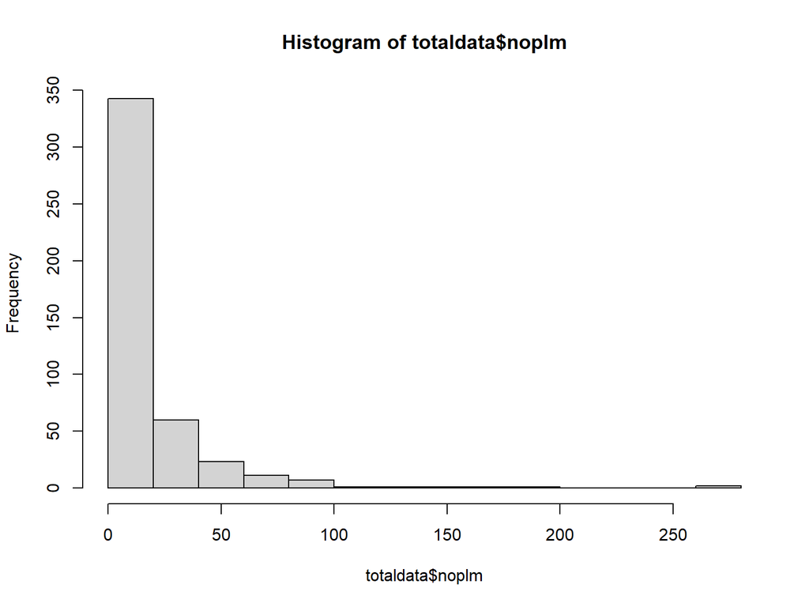

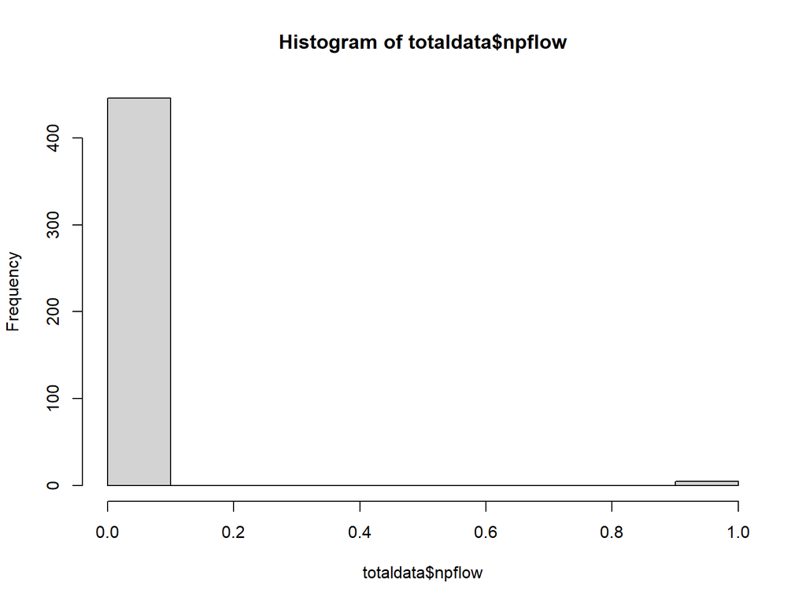

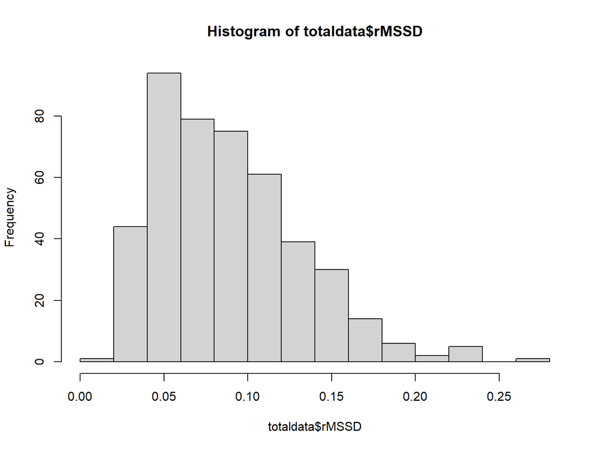

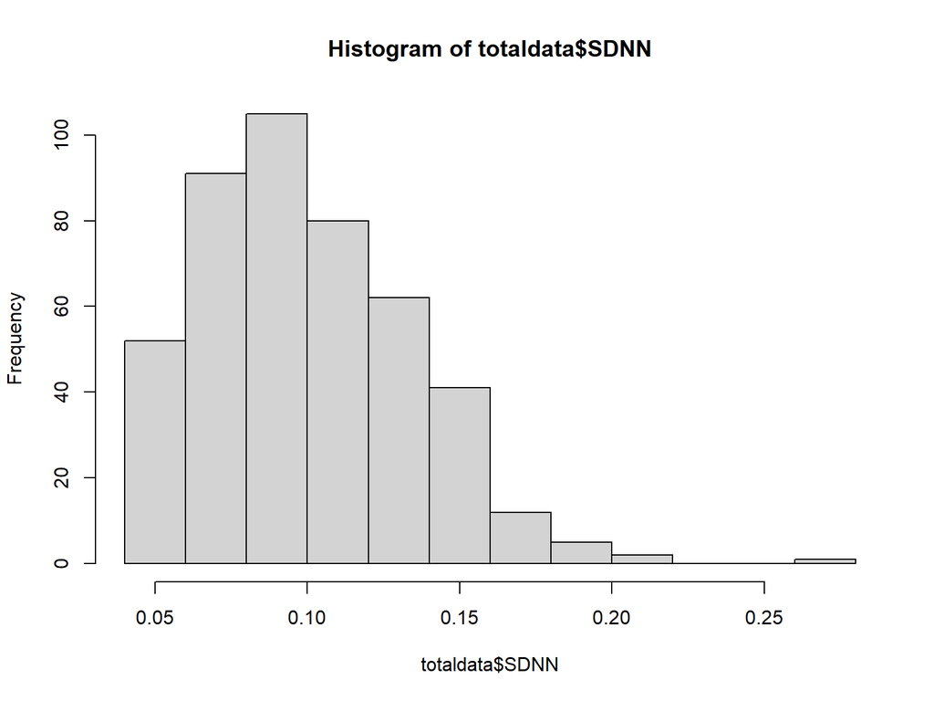

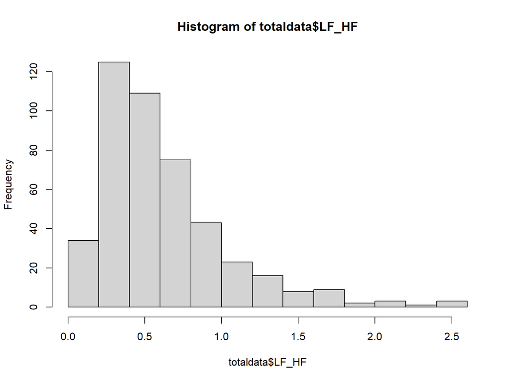

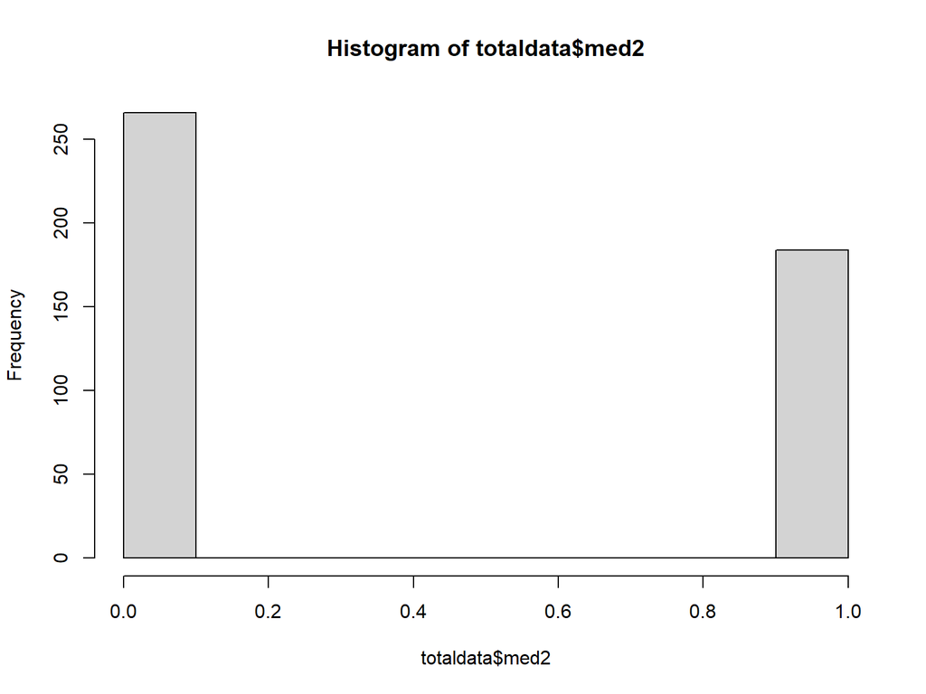

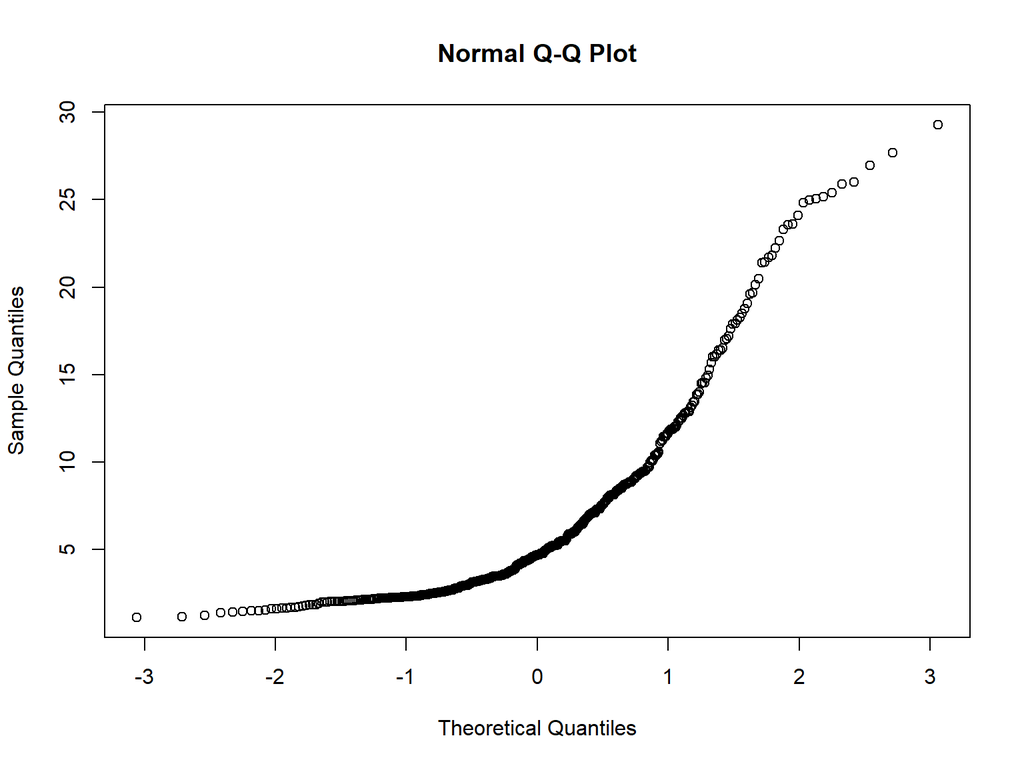

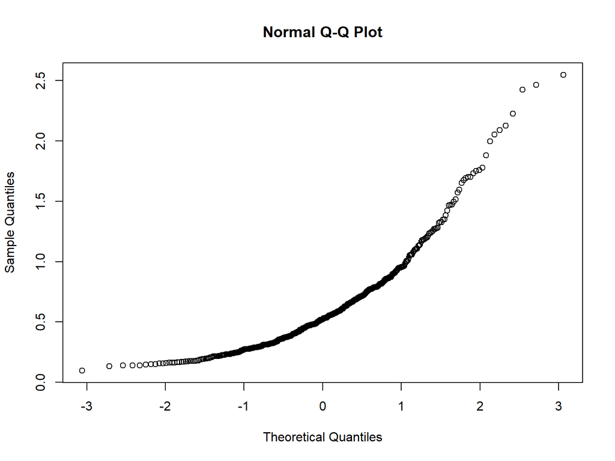

# ggplot

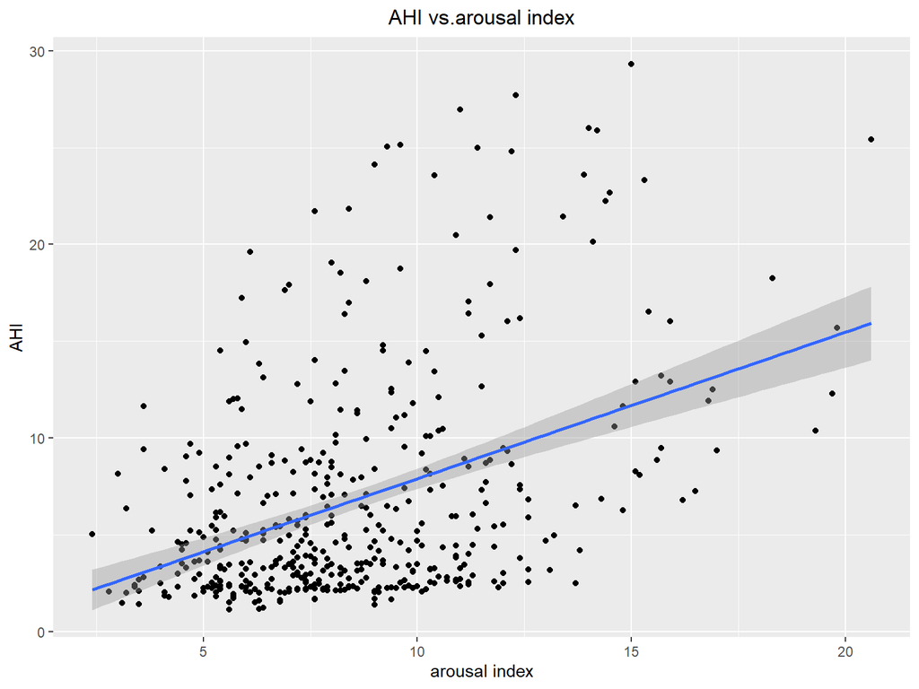

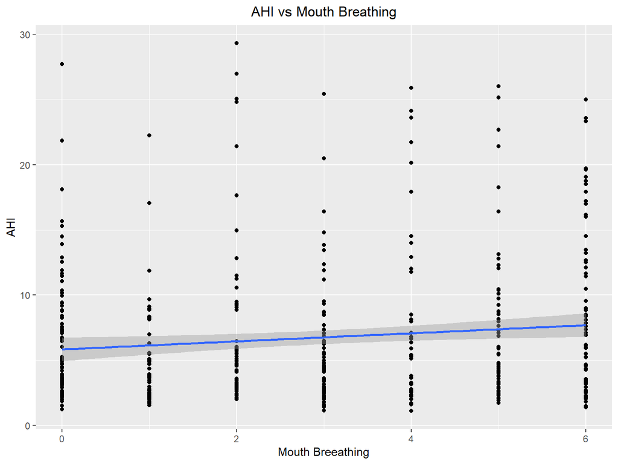

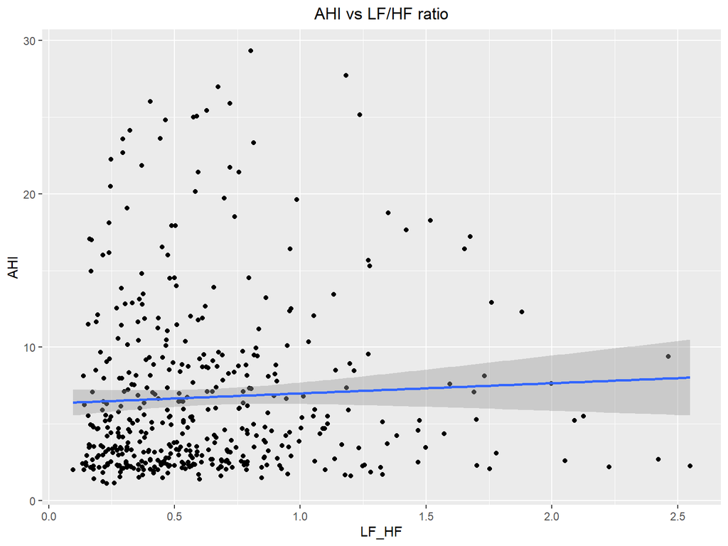

# Statistics

```
##
##  Wilcoxon rank sum test with continuity correction
##
## data:  totaldata$qsahi and totaldata$ai
## W = 60199, p-value < 2.2e-16
## alternative hypothesis: true location shift is not equal to 0
```

```
##
##  Wilcoxon rank sum test with continuity correction
##
## data:  totaldata$qsahi and totaldata$osa2a
## W = 146735, p-value < 2.2e-16
## alternative hypothesis: true location shift is not equal to 0
```

# Linear Regresssion RESULTS

Various models include: polysomnogram, history, physical exam, cognitive assesments and heart rate/wearables.

###Linear Regresssion-Final Model Results Based on most highly correlated, noninvasive variables

[output not shown]

# Linear Regresssion-Final Model

model=lm(qsahi~LF_HF + noplm+ rMSSD+ osa2a+psl3c+pe16_tonsilscale +ant5, data=totaldata) summary(model)

Residuals: Min 1Q Median 3Q Max -8.129 -3.539 -1.896 1.487 20.290

Residual standard error: 5.631 on 171 degrees of freedom (272 observations deleted due to missingness) Multiple R-squared: 0.06441, Adjusted R-squared: 0.02611 F-statistic: 1.682 on 7 and 171 DF, p-value: 0.1164

```
##
## Call:
## lm(formula = qsahi ~ LF_HF + noplm + rMSSD + osa2a + psl3c +
##     pe16_tonsilscale + ant5, data = totaldata)
##
## Residuals:
##    Min     1Q Median     3Q    Max
## -8.129 -3.539 -1.896  1.487 20.290
##
## Coefficients:
##                   Estimate Std. Error t value Pr(>|t|)
## (Intercept)      -1.278770   3.256902  -0.393   0.6951
## LF_HF             3.703790   1.578838   2.346   0.0201 *
## noplm             0.005035   0.014869   0.339   0.7353
## rMSSD            13.251886  12.112673   1.094   0.2755
## osa2a             0.275919   0.197127   1.400   0.1634
## psl3c            -0.038942   0.064816  -0.601   0.5488
## pe16_tonsilscale  0.863367   0.510360   1.692   0.0925 .
## ant5              0.039971   0.105897   0.377   0.7063
## ---
## Signif. codes:  0 '***' 0.001 '**' 0.01 '*' 0.05 '.' 0.1 ' ' 1
##
## Residual standard error: 5.631 on 171 degrees of freedom
##   (272 observations deleted due to missingness)
## Multiple R-squared:  0.06441,    Adjusted R-squared:  0.02611
## F-statistic: 1.682 on 7 and 171 DF,  p-value: 0.1164
```

# Conclusions

Limitations- selected population

Future-include children without OSA, further explore mouthbreathing and heartrate variability

PSG still the Gold Standard!